# Reproducible Research: Peer Assessment 1

Sandra Contreras

Sunday, March 15, 2015

### Loading and preprocessing the data

```r
activity <- read.table("activity.csv", header=T, quote="\"", sep=",")
head(activity)
```

```
##   steps       date interval
## 1    NA 2012-10-01        0
## 2    NA 2012-10-01        5
## 3    NA 2012-10-01       10
## 4    NA 2012-10-01       15
## 5    NA 2012-10-01       20
## 6    NA 2012-10-01       25
```

```r
dim(activity)
```

```
## [1] 17568     3
```

```r
object.size(activity)
```

```
## 215984 bytes
```

```r
names(activity)
```

```
## [1] "steps"    "date"     "interval"
```

```r
summary(activity)
```

```
##      steps                date          interval
##  Min.   :  0.00   2012-10-01:  288   Min.   :   0.0
##  1st Qu.:  0.00   2012-10-02:  288   1st Qu.: 588.8
##  Median :  0.00   2012-10-03:  288   Median :1177.5
##  Mean   : 37.38   2012-10-04:  288   Mean   :1177.5
##  3rd Qu.: 12.00   2012-10-05:  288   3rd Qu.:1766.2
##  Max.   :806.00   2012-10-06:  288   Max.   :2355.0
##  NA's   :2304     (Other)   :15840
```

```r
data <- na.omit(activity)
summary(data)
```

```
##      steps                date          interval
##  Min.   :  0.00   2012-10-02:  288   Min.   :   0.0
##  1st Qu.:  0.00   2012-10-03:  288   1st Qu.: 588.8
##  Median :  0.00   2012-10-04:  288   Median :1177.5
##  Mean   : 37.38   2012-10-05:  288   Mean   :1177.5
##  3rd Qu.: 12.00   2012-10-06:  288   3rd Qu.:1766.2
##  Max.   :806.00   2012-10-07:  288   Max.   :2355.0
##                   (Other)   :13536
```

```r
data$date <- as.Date(data$date)
```

### What is mean total number of steps taken per day?

1. Total number of steps taken per day

```r
stepsByday <- aggregate(data$steps, by=list(date=data$date), FUN=sum)
colnames(stepsByday) <- c("date", "steps")
head(stepsByday)
```

```
##         date steps
## 1 2012-10-02   126
## 2 2012-10-03 11352
## 3 2012-10-04 12116
## 4 2012-10-05 13294
## 5 2012-10-06 15420
## 6 2012-10-07 11015
```

2. Histogram of the total number of steps taken each day

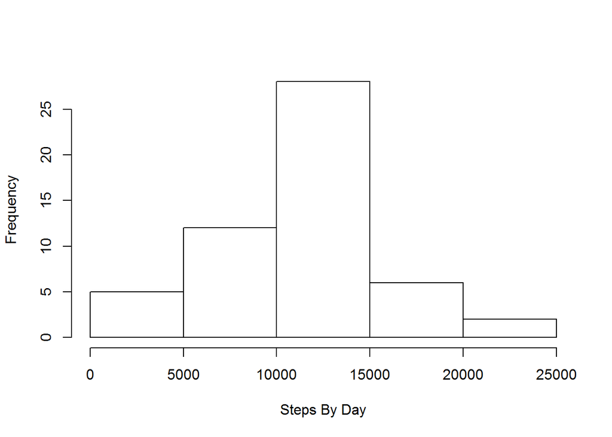

```r
hist(stepsByday$steps,main=" ",xlab="Steps By Day")
```

3. Report the mean and median of the total number of steps taken per day

```r
mean(stepsByday$steps);
```

```
## [1] 10766.19
```

```r
median(stepsByday$steps);
```

```
## [1] 10765
```

### What is the average daily activity pattern?

1. Make a time series plot (i.e. type = “l”) of the 5-minute interval (x-axis) and the average number of steps taken, averaged across all days (y-axis)

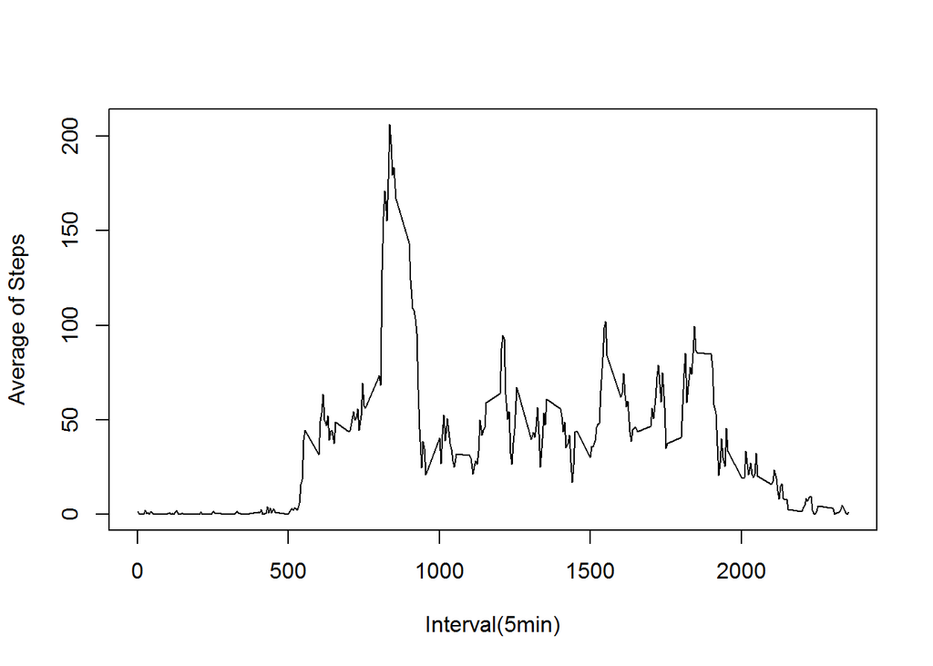

```r
stepsByInterval <- tapply(data$steps, data$interval, mean)

plot(row.names(stepsByInterval), stepsByInterval, type = "l", xlab = "Interval(5min)", ylab = "Average of Steps")
```

2. Which 5-minute interval, on average across all the days in the dataset, contains the maximum number of steps?

```r
interval <- which.max(stepsByInterval)
names(interval)
```

```
## [1] "835"
```